# Homework 1

Atakan Demirkan

4 Nisan 2021

# Part 1

I used readxl and zoo libraries.

```r
library("readxl")
library("zoo")
```

```r
basepath<-"C:\\Users\\aadem\\OneDrive\\Desktop\\"
```

## CPI Data of Turkey

### Obtaining Data

```r
CPI <- read_excel(path=paste(basepath,"CPI.xlsx",sep=""))
```

### Preparing Data

I prepared the data to make data types useful. I used transform function.

```r
CPI<-transform(CPI,CPI=as.numeric(CPI),Date=as.yearmon(Date))
```

### Plotting

Secondly, I made a line chart of CPI Data with plot function.

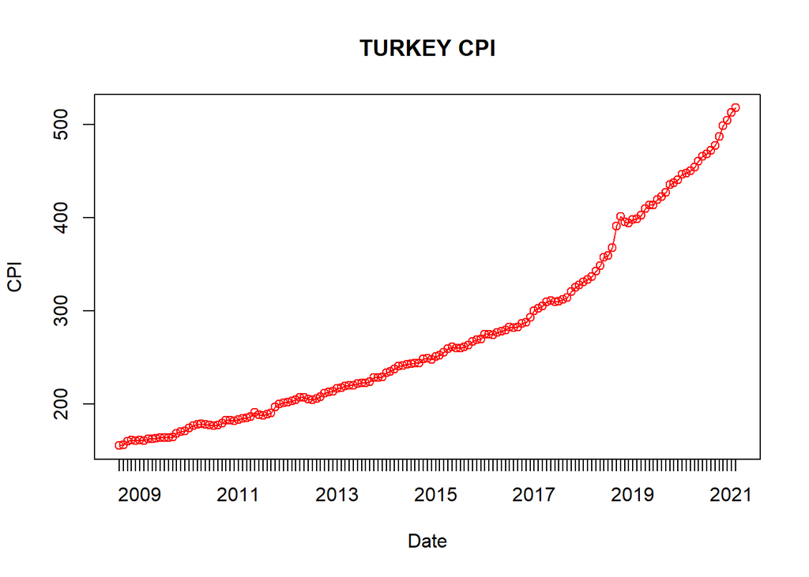

```r
plot(CPI,type = "o", col = "red", xlab = "Date", ylab = "CPI",
   main = "TURKEY CPI")
```

### Analysis

In CPI, there is a very clear increasing trend. It made sense while considering the dynamics of Turkish economy.Moreover, in last 4 years, there is a change in the slope of trend.

## USDTRY Data

### Obtaining Data

```r
USDTRY <- read_excel(path=paste(basepath,"USDTRY.xlsx",sep=""))
```

### Preparing Data

```r
USDTRY<-transform(USDTRY,USDTRY=as.numeric(USDTRY),Date=as.yearmon(Date))
```

### Plotting

Secondly, I made a line chart of USDTRY Data with plot function.

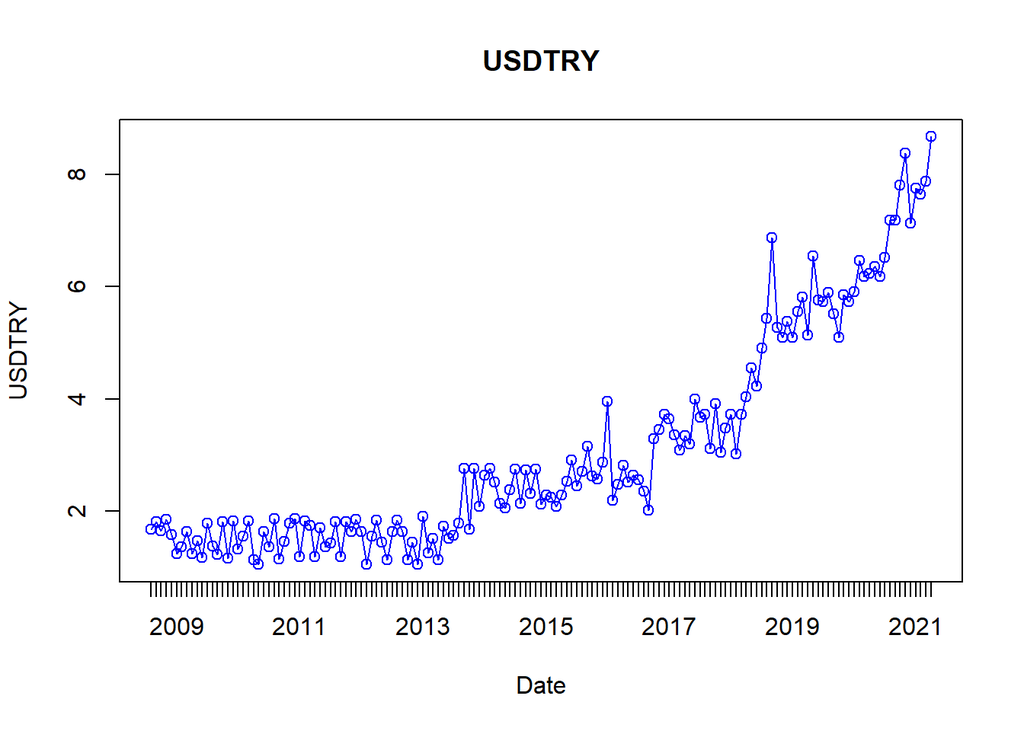

```r
plot(USDTRY,type = "o", col = "blue", xlab = "Date", ylab = "USDTRY",
   main = "USDTRY")
```

### Analysis

USDTRY can be divided into 3 parts. In 2009-2013, it made mean revertive actions in a range and converged to a fixed mean level. In 2013 and 2017, there was a shift according to first part but still it is in a fixed range. After 2017, there is a very clear increasing trend. In general there are some unusual obvervations such as 1Q2016 or 2Q2018.

## XAUTRY Data

### Obtaining Data

```r
XAUTRY <- read_excel(path=paste(basepath,"XAUTRY.xlsx",sep=""))
```

### Preparing Data

```r
XAUTRY<-transform(XAUTRY,XAUTRY=as.numeric(XAUTRY),Date=as.yearmon(Date))
```

### Plotting

Secondly, I made a line chart of XAUTRY Data with plot function.

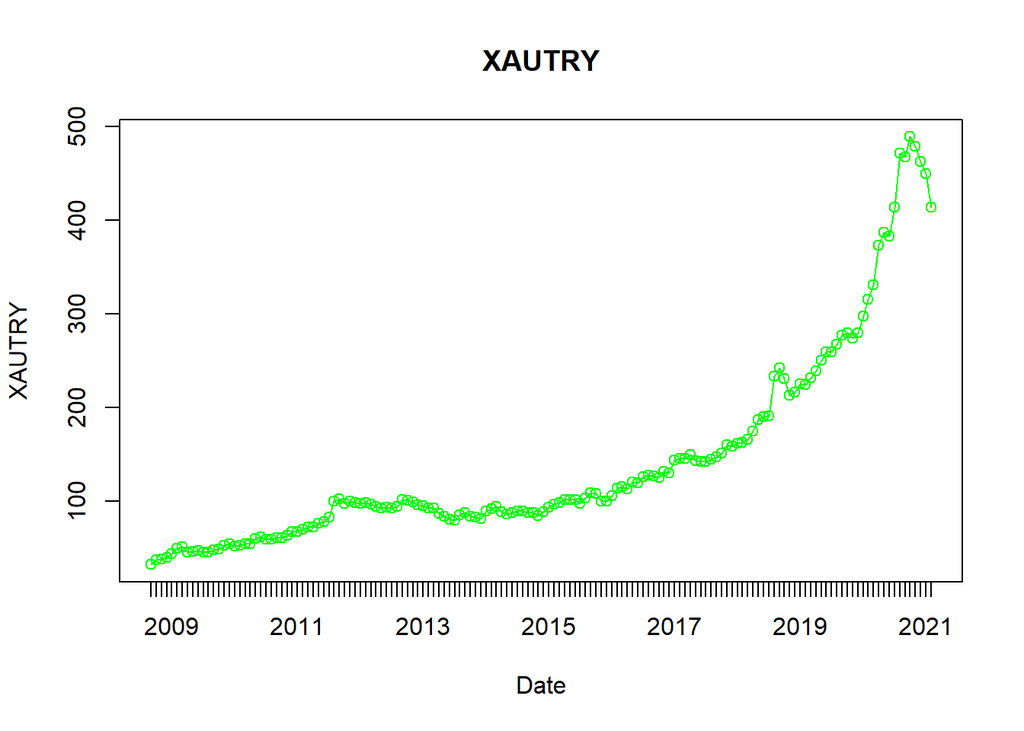

```r
plot(XAUTRY,type = "o", col = "green", xlab = "Date", ylab = "XAUTRY",
   main = "XAUTRY")
```

### Analysis

The behaviour of XAUTRY can be scrutunized in 3 different parts. In 2009-2011 there is a upward trend. After unsual observation in the end of 2011, it lost momentum and mmoved in a fixed range and display mean revertive behaviour. After it has an increasing trend with increasing acceleration. The 2Q of 2018 can be regarded as unsual observation.

## Comparative Analysis

CPI is the price of typcial consumer basket in TRY basis and Turkey is a emerging market. Thus, increasing trend in CPI is justifiable. However, in Turkey, there is a very strong dollarization. It means the prices of a considerable number of goods are affected by USDTRY. The value loss of TRY against USD after 2017 explains the slope change in CPI.

In addition, in 2009-2015 period, there are behavioral differences between XAUTRY and USDTRY. It can be explained by XAUUSD commodity price. The QE and Taper Tantrum process after GFC drove the convergence between XAUTRY and USDTRY.

Finally, after 2016, XAUTRY and USDTRY moved in a similar pattern despite some unsual observations. In this period, TRY drove the values of gold and usd price against TRY as denominator. The actions in XAUUSD didn’t prevent this similar move pattern. The reason can be the strong volatility of TRY according to gold or USD prices.

# Part 2

## USDTRY Currency and Google Trends Sentiment

I used gtrendsR, ggplot2 and reshape2 libraries.

```r
library("gtrendsR")
library("reshape2")
library("ggplot2")
```

I defined the keyword that I research.

```r
keywords=c("Dolar","Altın")
```

I defined the country of observations.

```r
country=c('TR')
```

I determine the time interval of my analysis.

```r
time=("2010-01-01 2021-04-01")
```

I selected only interest over time

```r
trends = gtrends(keywords, geo=country, time = time )
time_trend=trends$interest_over_time
```

I plotted.

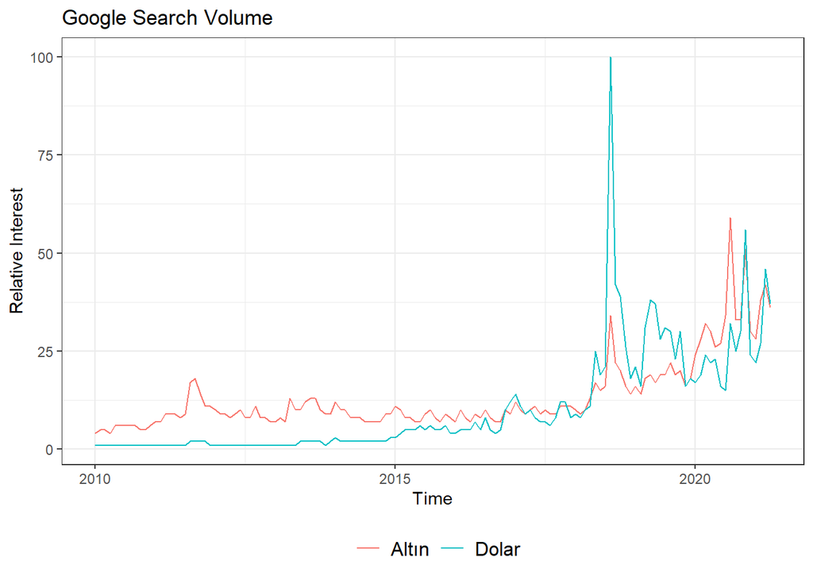

```r
plot<-ggplot(data=time_trend, aes(x=date, y=hits,group=keyword,col=keyword))+
        geom_line()+xlab('Time')+ylab('Relative Interest')+ theme_bw()+
        theme(legend.title = element_blank(),legend.position="bottom",legend.text=element_text(size=12))+ggtitle("Google Search Volume")
plot
```

## Comments

After analyzing the google trends volume of “dolar” word in Turkey, I found that there is no leading quality of citizens interest over USDTRY currency. However, extreme movements in currency cause some extreme interest in people and caught their attention. For instance, in the middle of 2018 currency shock, the sentiment went to extreme territory rapidly. It might be reasonable due to effect of USDTRY in CPI (explained before). Also, a considerable number of people invest in Us Dollar as a speculative purposes. Thus, extreme volatility caught their interest.Moreover, if we ignore the unusual observations, there is a clear level difference between the first and second half of sample. It can be explained by the increasing volatility in USDTRY.

For the word “Altın”, there is a similar pattern like USDTRY and XAUTRY similarity. But the level difference in 2010-2015 interval is interesting. It may be the result of social meaning such as gift of gold in Turkish society in addition to speculative characteristics.